## Act report for WeRateDogs

## Introduction

In this project, we studied the main section - Data Wrangling. In the project, we examined tweets from the WeRateDogs account, used 3 different sources and methods of data gather. So we use 3 main steps for Data Wrangling:

1) Gather

2) Assess

3) Clean

And after that we Anamyze and make visulization for data wrangling process, please refer to wrangle_act file for steps and codes.

### 1 insights. In these graphs, we can view a general picture of all the counts that we have. Let's pay attention to favorites and retweets.

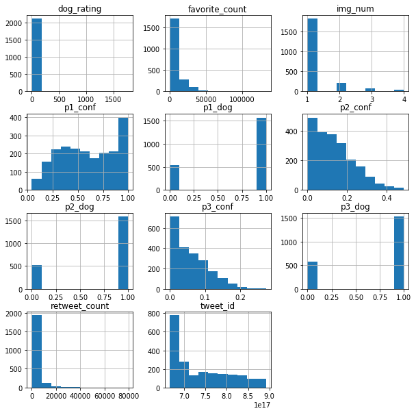

### 2 insights. Let's see TOP 5 more Favorite tweets

1) https://twitter.com/dog_rates/status/822872901745569793

2) https://twitter.com/dog_rates/status/744234799360020481

3) https://twitter.com/dog_rates/status/879415818425184262

4) https://twitter.com/dog_rates/status/807106840509214720

5) https://twitter.com/dog_rates/status/866450705531457537

### 3 insights. Let's see TOP 5 retweets

1) https://twitter.com/dog_rates/status/744234799360020481

2) https://twitter.com/dog_rates/status/807106840509214720

3) https://twitter.com/dog_rates/status/807106840509214720

4) https://twitter.com/dog_rates/status/739238157791694849

5) https://twitter.com/dog_rates/status/739238157791694849

We can see that there are two tweets in favorites and retweets, which have both a high favorite and retweets: 744234799360020481 and 807106840509214720

### 4 insights. Let's see TOP Dog kinds

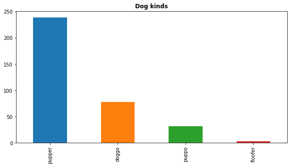

Pupper (239) is the most common stage in a dog's life for this analysis. pupper 239 doggo 78 puppo 32 floofer 3

### 5 insights. Top 5 Dog Predictions

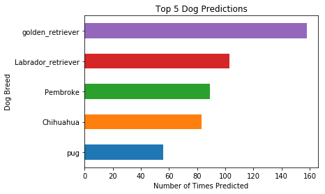

We can see from this graph that golden_retriever (158) and Labrador_retriever (103) are especially popular.

### 6 insights. Top 5 Dog Name

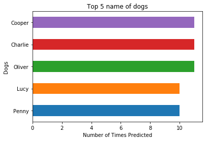

We have 3 dogs with the same high performance - Cooper, Charlie and Oliver (11)

### 7 insights. Favorites and Retweets

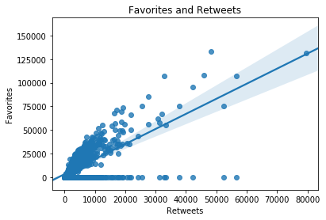

There is a strong connection between retweets and favorites. When a tweet gets Favorites, you can expect an increase in retweets and vice versa.

## Conclusion

Through this project, I learned the whole Data Wrangling process. We were able to directly connect to the desired API from the social network, like Twitter, and display the accounts and data we need from there. These skills can be used in any field to analyze the subjects and objects we need.